# ABL Trees

- Rotation formulas

## Rotation Formulas

We cover formula for :

1. LL Rotation
2. LR Rottation

From the above we can deduce RR amd RL Rotation.

## LL Rotation

We have the following tree:

**1. Initial**

```
                     height                        3-1=2                height
                     + 0-->                        +---+                <--0 +
                     |                             | A |                     |
                     |                           / +---+\                    |
                     |                          /    ^   \                   |
                     |                         /     |    \                  |
                     |                   +---+       |     +---+             |
            2-1=1    | 1-->              | B |       +     | ar|        <--1 |  0
                     |                  /+---+\ imbalanced +---+             |
                     |                 /       \                             |
                     |                /         \                            |
                     |             +---+         +---+                       |
                     |             | C |         |br |                       |
            1-1=0    | 2-->       /+---+\        +---+                  <--2 |
                     |           /       \                                   |
                     |          /         \                                  |
                     |       +---+         +---+                             |
                     |       |cl |         |cr |                             |
                0    v 3-->  +---+         +---+                        <--3 v
```

We wll be performing rotation node A which has become imbalanced. And we only address 3 nodes, since there may be many nodes around A, but we are addressing only:

1. A, B C

And since we only addressing those 3 nodes, we will be performing LL Rotation.

Observe:

1. Node A imbalance is 2
2. And Node A, lchild is 1
3. So we have LL imbalance and perform LL rotation.

(Aside if Node A, lchild is -1, then we will have to perform LR Imbalance.)

**2. After Rotation**

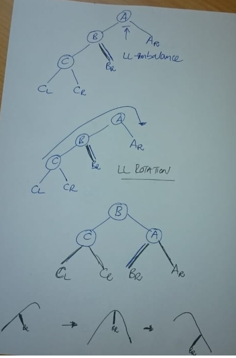

```
                                                   2-2=0
                            + 0-->                 +---+                   <--0 +
                            |                      | B |                        |
                            |                    / +---+ \                      |
                            |                   /         \                     |
                            |                  /           \                    |
                            |            +---+              +---+               |
                  1-1=0     | 1-->       | C |              | A |          <--1 | 1-1=0
                            |           /+---+\            /+---+\              |
                            |          /       \          /       \             |
                            |         /         \        /         \            |
                            |      +---+       +---+  +---+        +---+        |
                            |      | cl|       |cr |  |br |        |ar |        |
                   0   0    v 2--> +---+       +---+  +---+        +---+   <--2 v 0  0
```

## Another LL Example:

**1. Initial**

```
                     height                        3-2=1                  height
                     + 0-->                        +---+                  <--0 +
                     |                             |30 |                       |
                     |                           / +---+\                      |
                     |                          /        \                     |
                     |                         /          \                    |
                     |                   +---+             +---+               |
            2-2=0    | 1-->              |20 |             | 40|          <--1 |  0-1=-1
                     |                  /+---+\            +---+\              |
                     |                 /       \                 \             |
                     |                /         \                 \            |
                     |             +---+         +---+             +---+       |
                     |             |10 |         |25 |             | 50|       |  0
            1-1=0    | 2-->       /+---+\        +---+ \           +---+  <--2 |
                     |           /       \              \                      |
                     |          /         \              \                     |
                     |       +---+         +---+          +---+                |
                     |       | 5 |         | 15|          |28 |                |
            0 0 0    v 3-->  +---+         +---+          +---+           <--3 v
```

**2. After insert** Insert Node 4

[output not shown]

Observation:

1. Insertion was done Left, left, left, left
2. First three "lefts" is enough for me.
3. That means LL imbalance
4. So we can perform LL Rotation.

**3. After Rotation**

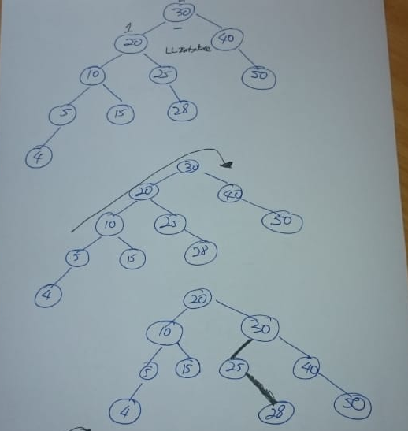

Observations:

```
                      height                       3-3=0                          height
                      + 0-->                       +---+                          <--0 +
                      |                            |20 |                               |
                      |                          / +---+ \                             |
                      |                         /         \                            |
                      |                        /           \                           |
                      |                  +---+              +---+                      |
             2-1=1    | 1-->             |10 |              | 30|                 <--1 |  2-2=0
                      |                 /+---+\            /+---+\                     |
                      |                /       \          /       \                    |
                      |               /         \        /         \                   |
                      |            +---+       +---+  +---+         +---+              |
                      |            | 5 |       |15 |  |25 |         | 40|              |
             1-1=0    | 2-->      /+---+       +---+  +---+\        +---+\        <--2 | 0-1=-1
             0        |          /                          \             \            | 0-1=-1
                      |         /                            \             \           |
                      |      +---+                           +---+         +---+       |
                      |      | 4 |                           | 28|         |50 |       |
             0 0 0    v 3--> +---+                           +---+         +---+  <--3 v
```

## LR Rotation

**1. Initial**

```
             height                       3-1=2              height
             + 0-->                       +---+              <--0 +
             |                            | A |                   |
             |                          / +---+ \                 |
             |                         /    ^    \                |
             |                        /     |     \               |
             |                  +---+       |      +---+          |
    1-2=-1   | 1-->             | B |       +      | Ar|     <--1 |  0
             |                 /+---+\  imbalanced +---+          |
             |                /       \                           |
             |               /         \                          |
             |            +---+       +---+                       |
             |            | Bl|       | C |                       |
    1-1=0    | 2-->       +---+      /+---+\                 <--2 |
    0        |                      /       \                     |
             |                     /         \                    |
             |                  +---+         +---+               |
             |                  |Cl |         |Cr |               |
    0 0 0    v 3-->             +---+         +---+          <--3 v
```

Observations

1. Where we have from imbalanced Node, its :
   - lchild = 2
   - and then its rchild = -1
2. Then we have LR Imbalance

Observation:

**2. After Rotation**

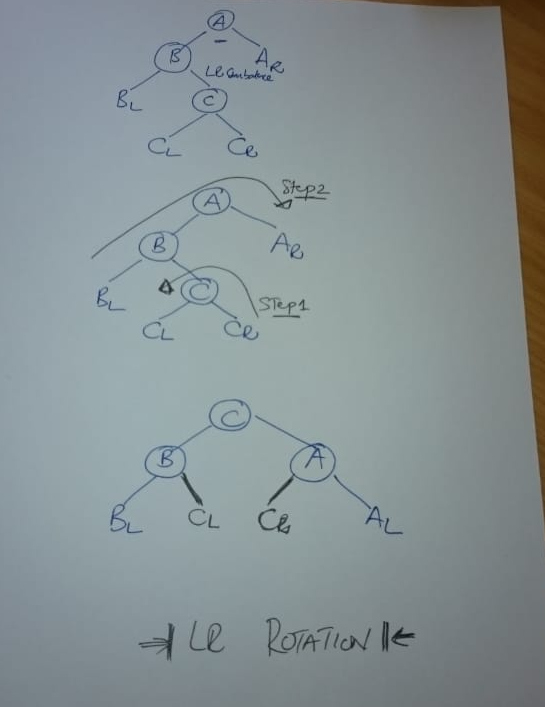

Observations:

1. Node C goes to Node A
2. And Node B remains as is.
3. Node A becomes rchild of Node C
4. Node Cl , remains on LHS of node C, but its rchild of Node B
5. Node Cr , remains on RHS of node C, but its lchild of Node A
6. Again we only interact with 3 nodes.

```
             height                       2-2=0                              height
             + 0-->                       +---+                              <--0 +
             |                            | C |                                   |
             |                          / +---+ \                                 |
             |                         /         \                                |
             |                        /           \                               |
             |                  +---+              +---+                          |
    1-1=0    | 1-->             | B |              | A |                     <--1 | 1-1=0
             |                 /+---+\            /+---+\                         |
             |                /       \          /       \                        |
             |               /         \        /         \                       |
             |            +---+       +---+  +---+         +---+                  |
             |            | Bl|       |Cl |  |Cr |         |Ar |                  |
       0 0   v 2-->       +---+       +---+  +---+         +---+             <--2 v  0 0
```

## Another LR Rotation

**1. Initial**

[output not shown]

**2. After insert** Insert Node 27

[output not shown]

Observations

1. We inserted Left, Right, Left, Right
2. The first LR is suffucient to know that we have LR imbalance.
3. We also know we have LR imbalance, where:
   - lchild = 2
   - and then its rchild = -1
4. Then we have LR Imbalance

**2. After Rotation**

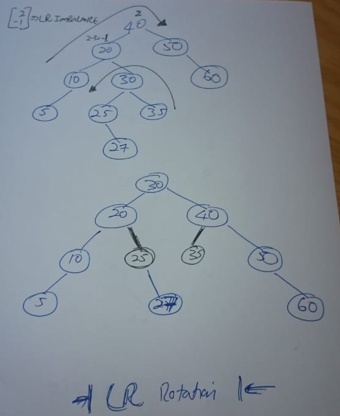

Observations:

1. Node 30 goes to Node 40
2. And Node 20 remains as is.
3. Node 40 becomes rchild of Node 30
1. Node 25, remains on LHS of node 30, but its rchild of Node 20
2. Node 35, remains on RHS of node 30, but its lchild of Node 40
3. Again we only interact with 3 nodes.
4. Everything else, keep the same position and direction.

```
             height                       3-3=0                       height
             + 0-->                       +---+                       <--0 +
             |                            |30 |                            |
             |                          / +---+ \                          |
             |                         /         \                         |
             |                        /           \                        |
             |                  +---+              +---+                   |
    2-2=0    | 1-->             | 20|              | 40|              <--1 |  1-2=-1
             |                 /+---+\            /+---+\                  |
             |                /       \          /       \                 |
             |               /         \        /         \                |
             |            +---+       +---+  +---+       +---+             |
             |            | 10|       | 25|  |35 |       |50 |             |
    1-0=1    | 2-->      /+---+       +---+\ +---+       +---+\       <--2 |  0-1=-1
    0-1=-1   |          /                   \                  \           |
             |         /                     \                  \          |
             |      +---+                     +---+            +---+       |
             |      | 5 |                     |27 |            |60 |       |
    0 0      v 3--> +---+                     +---+            +---+  <--3 v  0
```

## What does code do

1. Setup as we did with BST, with Node
2. Add height property to Node
3. We use the recursive insert.
4. When wd do the recursive insert
   - we also set the height:
5. Remember height start at 0, as we have defined it
6. However, we wil start at 1. (Could also just make it 0, but keep it as the lesson content)
   - This does not make any difference to out criteria of {-1,0,1}

```
t->height=1;
```

1. After each insert, we need to update the height for every node (subtree).
   - We will write a define a function for calculating this value
   - This is just it: The height of that node.

```
p->NodeHeight(p)
```

We setting the Node Height as follows:

```
                     + 1-->                        +---+                <--1 +
                     |                             |   |                     |
                     |                           / +---+ \                   |
                     |                          /         \                  |
                     |                         /           \                 |
                     |                   +---+              +---+            |
                     v 2-->              | p |              |   |       <--2 v
                                         +---+              +---+
```

1. From the above the height of p is 2.
2. But if we add another node on LHS, that is lchild of p:
3. Then height of p (lchild) will be 3.

```
                                                     3
                     + 1-->                        +---+                <--1 +
                     |                             |   |                     |
                     |                           / +---+ \                   |
                     |                          /         \                  |
                     |                         /           \                 |
                     |                   +---+              +---+            |
                     | 2-->              | p |              |   |       <--2 |
                     |                  /+---+              +---+            |
                     |                 /                                     |
                     |                /                                      |
                     |          +---+                                        |
                     |          |   |                                        |
                     v 3-->     +---+                                   <--3 v
```

1. That is we take the longest side and add 1 to it:

```
int NodeHeight(Node *p){
  int hl, hr;
  hl=p && p->lchild?p-lchild->height:0;
  hr=p && p->rchild?p-rchild->height:0;

  return hl>hr>h1+1:hr+1;
}
```

1. After we have inserted the new node, we need to make sure that the BST is an AVL, that is, if it is balanced
2. So in order to ensure we have an AVL tree, we need to first get:
   - balancing factor
     - Define a function for finding the balancinf factor
     - Code is similar to finding the height instead, we perform: $hl-hr$
   - then do rotation.

```
int BalanceFactor(Node *p){
  int hl, hr;
  hl=p && p->lchild?p-lchild->height:0;
  hr=p && p->rchild?p-rchild->height:0;

  return hl-hr;
}
```

```
if (BalanceFactor(p)==2 && BalanceFactor(p-lchild==1)
    return LLRotation(p)
else if (BalanceFactor(p)==2 && BalanceFactor(p-lchild==-1)
    return LRRotation(p)
else if (BalanceFactor(p)==-2 && BalanceFactor(p-lchild==-1)
    return RRRotation(p)
else if (BalanceFactor(p)==-2 && BalanceFactor(p-lchild==1)
    return RLRotation(p)
```

1. Then we define all these rotatons. lets take LLRotation:

Lets first think about it, we have:

```
                                                   +---+
                                                   | p |
                                                 / +---+ \
                                                /         \
                                               /           \
                                         +---+              +---+
                                         | pl|              |   |
                                        /+---+\             +---+
                                       /       \
                                      /         \
                                +---+            +---+
                                |   |            |plr|
                               /+---+\           +---+
                              /       \
                             /         \
                          +---+         +---+
                          |   |         |   |
                          +---+         +---+
```

```
                                                   +---+
                                                   |pl |
                                                 / +---+ \
                                                /         \
                                               /           \
                                           +---+            +---+
                                           |   |            | p |
                                           +---+           /+---+\
                                                          /       \
                                                         /         \
                                                      +---+         +---+
                                                      |plr|         |   |
                                                      +---+         +---+
```

1. After the rotation we need to take height again/balancing factor again.
2. Also update the Nodeheight of:
   - p
   - pl
3. When done return pl which is the new root.
4. Lets define, LL Rotation:

```
Node* LLRotation(Node *p){
  Node *pl = p->lchild
  Node *plr = pl->rchild

  pl->rchild = p;
  p->lchuild = plr;
  p->height = NodeHeight(p);
  pl->height = NodeHeight(pl);

  if (root ==p)
   root = pl;
  return pl;
}
```

1. Lets consider LR Rotation. To perform LR Rotation, we need:
   - p (thats where we will perfrom the rotation
   - p's lchild, that is pl
   - p's lchild's rchild, that is plr
2. Initial we will have:

```
                                              +---+
                                              |pl |
                                            / +---+ \
                                           /         \
                                          /           \
                                    +---+              +---+
                                    |pl |              | p |
                                   /+---+\             +---+
                                  /       \
                                 /         \
                              +---+         +---+
                              |   |        /|plr|\
                              +---+       / +---+ \
                                         /         \
                                      +---+         +---+
                                      | l |         | r |
                                      +---+         +---+
```

1. After the rotation we will get:

```
                                              +---+
                                              |plr|
                                            / +---+ \
                                           /         \
                                          /           \
                                    +---+              +---+
                                    |pl |              | p |
                                   /+---+\            /+---+
                                  /       \          /
                                 /         \        /
                              +---+         +---++---+
                              |   |         | l || r |
                              +---+         +---++---+
```

1. From the above we can see we will need 4 pointers:
   - Pointer to Node p
   - Node p lchild, that is pl
   - Node p lchild's right child, plr
   - Node plr lchild and rchild

```
Node* LRRotation(Node *p){
  Node *pl = p->lchild;
  Node *plr = pl->rchild;

  //Rotation
  pl->rchild = plr->lchild;
  p->lchild = plr->rchild;


  plr->lchild = pl;
  plr->rchild = p;

  //need  to find height of p, pl and plr
  p->height = NodeHeight(p);
  pl->height = NodeHeight(pl);
  plr->height = NodeHeight(plr);

  if (root ==p)
   root = plr;
  return plr;
}
```

```python
#include <iostream>
#include <climits>
#include <math.h>
#define INSERTION_OPERATOR operator<<
#define EXTRACTION_OPERATOR operator>>
#define ADDITION_OPERATOR operator+
using namespace std;
```

```python
class Node{
public:
    Node *lchild;
    int data;
    int height;
    Node *rchild;
}*root=NULL;
```

```python
int BalanceFactor(Node *p){
  int hl, hr;
  hl=p && p->lchild?p->lchild->height:0;
  hr=p && p->rchild?p->rchild->height:0;

  return hl-hr;
}
```

```python
int NodeHeight(Node *p){
  int hl, hr;
  //p is not null, then take height of p's lchild, else if null, make it=0
  hl=p && p->lchild?p->lchild->height:0;
  hr=p && p->rchild?p->rchild->height:0;

  return hl>hr?hl+1:hr+1;

}
```

```python
Node* LLRotation(Node *p){
  Node *pl = p->lchild;
  Node *plr = pl->rchild;

  pl->rchild = p;
  p->lchild = plr;
  p->height = NodeHeight(p);
  pl->height = NodeHeight(pl);

  if (root ==p)
   root = pl;
  return pl;
}
```

```python
Node* RRRotation(Node *p){
  return NULL;
}
```

```python
Node* LRRotation(Node *p){
  Node *pl = p->lchild;
  Node *plr = pl->rchild;

  //Rotation
  pl->rchild = plr->lchild;
  p->lchild = plr->rchild;


  plr->lchild = pl;
  plr->rchild = p;

  //need  to find height of p, pl and plr
  p->height = NodeHeight(p);
  pl->height = NodeHeight(pl);
  plr->height = NodeHeight(plr);

  if (root ==p)
   root = plr;
  return plr;
}
```

```python
Node* RLRotation(Node *p){
  return NULL;
}
```

```python
Node* RInsert(Node *p, int key){
  Node *t = NULL;

  if (p==NULL){
     t = new Node;
     t->data= key;
     t->height=1;
     t->lchild = t->rchild = NULL;
     return t;
  }

  if (key< p->data)
      p->lchild= RInsert(p->lchild, key);
  else if (key > p->data)
      p->rchild= RInsert(p->rchild, key);

  p->height=NodeHeight(p);

  if (BalanceFactor(p)==2 && BalanceFactor(p->lchild)==1)
    return LLRotation(p);
  else if (BalanceFactor(p)==2 && BalanceFactor(p->lchild)==-1)
    return LRRotation(p);
  else if (BalanceFactor(p)==-2 && BalanceFactor(p->rchild)==-1)
    return RRRotation(p);
  else if (BalanceFactor(p)==-2 && BalanceFactor(p->rchild)==1)
    return RLRotation(p) ;

  return p;

}
```

```python
void Inorder(Node *p){
   if(p)
   {
       Inorder(p->lchild);
       cout<<p->data<< " ";
       Inorder(p->rchild);
   }
}
```

```python
//10,5,2 (left left left, 5 becomes new root)
root=RInsert (root,10);
RInsert (root,5);
RInsert (root,2);
//After LLRotation
//2, 5, 10
Inorder(root);
```

```
2 5 10
```

```python
//50, 10, 20
root=NULL;
root=RInsert (root,50);
RInsert (root,10);
RInsert (root,20);
//After LRRotation
//10, 20, 50
Inorder(root);
```

```
10 20 50
```